# Лекция 9. Разность разностей

Блок 2. Панель RLMS

Карен Аванесян

Каузальный анализ в R на данных RLMS-HSE

# Зачем

## Политика как эксперимент

- Государство меняет правила **для одних и не для других**, или **с какого-то момента**. Это не рандомизация, но это вариация, которую люди не выбирают сами
- **Разность разностей** (DiD): сравниваем изменение исхода в затронутой группе с изменением в незатронутой. Второе изменение — оценка того, что произошло бы с первой группой **без** политики
- Рабочая лошадь оценки политик: минимальная зарплата, пособия, реформы образования, пенсионный возраст

DiD снимает два вида смещения сразу: постоянные различия между группами (как FE) и общие во времени шоки (как year FE). Остаётся допущение о **параллельных трендах**.

## Пример занятия: материнский капитал

1.01.2007 старт выплаты за второго и последующих детей

250 тыс. руб. с индексацией — около 10 средних годовых зарплат

20–39 лет матери против бездетных

кто затронут

### Женщины, у которых уже есть ребёнок

Следующий принесёт капитал. Бездетные при первом рождении (до 2020 г.) не получали ничего

Slonimczyk & Yurko 2014

### Повторим логику на RLMS

Они нашли рост вероятности вторых рождений. Исход — рождение ребёнка в год $t$ (по ростеру)

```r
w |> group_by(mother, post) |> summarise(n = n(), `рождений в год` = mean(birth), .groups = "drop")
```

| mother | post | n | рождений в год |
| --- | --- | --- | --- |
| 0 | 0 | 4019 | 0.105 |
| 0 | 1 | 6205 | 0.098 |
| 1 | 0 | 8489 | 0.033 |
| 1 | 1 | 12326 | 0.049 |

## План занятия

1. Арифметика 2 × 2 и регрессионная форма
2. Параллельные тренды: что это и как проверять
3. Динамический DiD = event study с контрольной группой
4. Плацебо и ложные пороги
5. Стандартные ошибки и уровень кластеризации
6. Как читать вывод `feols()` и `wald()` и писать результат
7. Что DiD не умеет

# Идея

## Арифметика 2 × 2

|  | До | После | Разность |
| --- | --- | --- | --- |
| **Затронутые** (матери) | $\bar y_{T,0}$ | $\bar y_{T,1}$ | $\Delta_T$ |
| **Незатронутые** (бездетные) | $\bar y_{C,0}$ | $\bar y_{C,1}$ | $\Delta_C$ |
|  |  |  | **DiD** $= \Delta_T - \Delta_C$ |

Регрессионная форма — одна строка:

$$y_{it} = \alpha + \beta\, \text{Treat}_i + \gamma\, \text{Post}_t + \tau\, (\text{Treat}_i \times \text{Post}_t) + \varepsilon_{it}$$

- $\tau$ = DiD; $\beta$ — постоянная разница групп; $\gamma$ — общий сдвиг во времени
- С многими годами и группами: $y_{it} = \tau D_{it} + \alpha_i + \lambda_t + \varepsilon$ — двусторонние FE (TWFE)

## Параллельные тренды

**Без политики** разность между группами осталась бы такой же, как до неё: $E[y_{T,1}(0) - y_{T,0}(0)] = E[y_{C,1} - y_{C,0}]$.

- Это утверждение о **контрфакте** — проверить напрямую нельзя
- Косвенно: тренды **до** политики параллельны? (несколько предпериодов)
- Чувствительно к **функциональной форме**: параллельны в уровнях ≠ параллельны в логарифмах
- Группы могут **различаться по уровню** сколько угодно — это DiD прощает. Не прощает различия в **динамике**: если у одной группы исход и так рос быстрее
- Антиципация: если люди реагируют на объявление (май 2006), «до» уже заражено

## Динамический DiD

Вместо одного Post — индикатор на каждый год, умноженный на группу:

$$y_{it} = \sum_{k \ne 2006} \tau_k \, \mathbb{1}[t = k] \times \text{Treat}_i + \alpha_i + \lambda_t + \varepsilon_{it}$$

- $\tau_k$ для $k < 2007$ — **предтренды**: должны быть ≈ 0
- $\tau_k$ для $k \ge 2007$ — эффект по годам: его динамика сама по себе результат (с лагом ли, нарастает ли)
- Это event study из лекции 8, но с группой сравнения, которая «переживает» те же годы без воздействия
- Базовый год — последний перед политикой

## Что ещё надо проверить

| Проверка | Что делаем |
| --- | --- |
| **Плацебо по времени** | «Включаем» политику в 2004 г. на предпериоде — эффект должен быть 0 |
| **Плацебо по группе** | Группа, которая точно не затронута (мужчины? женщины 45+?) — эффект 0 |
| **Плацебо по исходу** | Исход, на который политика не может влиять |
| **Состав групп** | Не меняется ли из-за политики, кто попадает в «матери» (composition) |
| **Чувствительность к предтрендам** | Насколько большое нарушение параллельности убьёт результат (`HonestDiD`) |

## Стандартные ошибки в DiD

- Bertrand, Duflo, Mullainathan (2004): серийная корреляция внутри групп делает наивные ошибки в DiD в разы меньше истинных
- Кластеризовать по уровню, на котором **назначается воздействие**: регион, если политика региональная; здесь — статус матери индивидуален, кластеризуем по человеку или площадке
- Мало кластеров (< 30) — wild cluster bootstrap
- Чем длиннее панель, тем важнее кластеризация, а не робастные ошибки

# Код

## DiD 2 × 2 руками

```r
cells <- w |> filter(year %in% 2003:2006 | year %in% 2008:2011) |>
  mutate(period = ifelse(year <= 2006, "до", "после")) |>
  group_by(mother, period) |> summarise(birth = mean(birth), .groups = "drop") |>
  pivot_wider(names_from = period, values_from = birth) |>
  mutate(разность = после - до)
cells
```

| mother | до | после | разность |
| --- | --- | --- | --- |
| 0 | 0.098 | 0.098 | 0.000 |
| 1 | 0.035 | 0.051 | 0.015 |

```r
c(DiD = diff(cells$разность))
```

```
   DiD
0.0149
```

2007 год исключён: родившиеся в 2007-м были зачаты до вступления закона в силу — «переходный» год.

## То же регрессией, с контролями

```r
dd <- w |> filter(year != 2007) |> mutate(post = as.integer(year >= 2008))
m_did <- feols(birth ~ mother:post + mother:(age + I(age^2)) + i(educ_level) | year + site,
               data = dd, cluster = ~psu)
etable(m_did, keep = "post", depvar = FALSE, fitstat = ~ n)
```

|  | m_did |
| --- | --- |
| mother x post | 0.029*** (0.006) |
| _______________ | ________________ |
| S.E.: Clustered | by: psu |
| Observations | 28,546 |

+2.9 п.п. при базовом уровне 3.3 % — вероятность рождения у матерей выросла на **88 %** относительно динамики бездетных. Группы имеют разные возрастные профили рождаемости, поэтому возраст входит с взаимодействием.

## Как читать вывод `feols()`: DiD 2 × 2

- Вывод R
- С пояснениями

```
OLS estimation, Dep. Var.: birth
Observations: 28,546
Fixed-effects: year: 11,  site: 39
Standard-errors: Clustered (psu)
                                      Estimate Std. Error t value    Pr(>|t|)
mother:post                           0.029132   0.006206   4.695 0.000036095 ***
mother:age                           -0.001047   0.000681  -1.537 0.132706118
mother:I(I(age^2))                   -0.000043   0.000015  -2.856 0.006991926 **
RMSE: 0.238075     Adj. R2: 0.018956
                 Within R2: 0.01796
```

1 · шапка

`Observations` — женщино-годы (2007 исключён); `Fixed-effects` — FE года и площадки: они поглощают общий шок времени и постоянные различия мест

2 · ошибки

`Clustered (psu)`: 38 кластеров. t-тесты идут с $G - 1$ степенями свободы — при малом $G$ p-value честнее, чем по числу наблюдений

3 · `mother:post`

Это $\tau$ — оценка DiD. Исход 0/1, поэтому 0.029 = **+2.9 п.п.** к годовой вероятности рождения

4 · основные эффекты

`post` поглощён FE года; различие групп задано возрастным профилем `mother:age`, `mother:I(age^2)` — это контроли, их не интерпретируем

5 · $R^2$

Within $R^2$ ≈ 0.02 — норма для редкого события. DiD отвечает на вопрос о сдвиге, а не об объяснённой дисперсии

6 · сигналы беды

Ошибки не кластеризованы; кластеров < 30; эффект сравним с базовым уровнем; сама таблица **ничего не говорит** о параллельных трендах

## Динамический DiD

- Результат
- Код

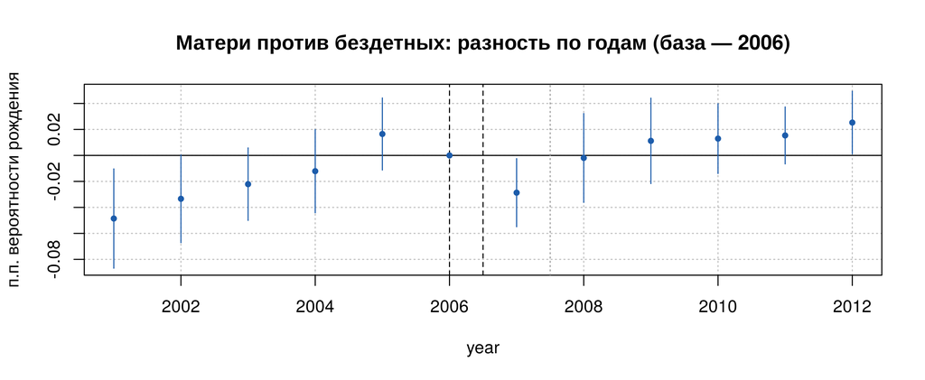

```r
es <- feols(birth ~ i(year, mother, ref = 2006) + mother:(age + I(age^2)) + i(educ_level) | year + site,
            data = w, cluster = ~psu)
iplot(es, main = "Матери против бездетных: разность по годам (база — 2006)",
      xlab = NULL, ylab = "п.п. вероятности рождения", col = pal["indigo"], ci.width = 0)
abline(v = 2006.5, lty = 2); abline(v = 2007.5, lty = 3, col = "grey60")
```

## Как читать график

2008–2012

### Рост до +1.5–2.5 п.п.

Эффект как будто появляется с лагом (беременность) и не исчезает

2007

2001–2005

### Снизу вверх

От −0.05 к +0.02: разность между группами росла задолго до программы

Если продолжить предтренд за 2006 г., «эффект» после 2008 г. оказывается **ниже** линии тренда. Проверим это плацебо и групповым трендом.

## Как читать вывод: event study и тест предтрендов

- Вывод R
- С пояснениями

```
Standard-errors: Clustered (psu)
                                      Estimate Std. Error t value   Pr(>|t|)
year::2001:mother                    -0.048565   0.018839 -2.5779 0.01405657 *
year::2002:mother                    -0.033376   0.016641 -2.0056 0.05225475 .
year::2003:mother                    -0.022124   0.013751 -1.6089 0.11613057
year::2004:mother                    -0.012110   0.015779 -0.7674 0.44768842
year::2005:mother                     0.016494   0.013668  1.2068 0.23518571
year::2007:mother                    -0.028675   0.012923 -2.2189 0.03271121 *
year::2008:mother                    -0.001942   0.016849 -0.1152 0.90887705
year::2009:mother                     0.011205   0.016208  0.6914 0.49365688
year::2010:mother                     0.012952   0.013225  0.9793 0.33377861
year::2011:mother                     0.015387   0.010789  1.4262 0.16218270
year::2012:mother                     0.025296   0.011861  2.1327 0.03965146 *
```

```
Wald test, H0: joint nullity of year::2001:mother, year::2002:mother, year::2003:mother, year::2004:mother and year::2005:mother
 stat = 4.46753, p-value = 0.002769, on 5 and 37 DoF, VCOV: Clustered (psu).
```

1 · имена

`year::2003:mother` — $\tau_{2003}$: разность «матери − бездетные» в 2003 г. **минус** та же разность в 2006 г. Базового года в таблице нет — он ноль по построению

2 · 2001–2005

Предтренды. По одному: часть незначима. Но читать их надо **вместе** и смотреть на форму: здесь они монотонно растут к 2006 г.

3 · 2007–2012

Эффект по годам после программы; 2007 — переходный (зачаты до закона). Их динамика — сама по себе результат

4 · `wald()`

H0: все пять предкоэффициентов равны нулю. `stat` — F(5, 37); второе число = кластеры − 1; VCOV тот же, кластерный

5 · вердикт

F = 4.47, p = 0.0028: параллельность до программы **отвергнута**, хотя по отдельности не все предкоэффициенты значимы

6 · сигналы беды

Монотонный дрейф предкоэффициентов; p > 0.05 при широких интервалах — это малая мощность, а не доказательство параллельности; регулярка `keep` захватила лишние годы

## Плацебо по времени

Ложный «старт» программы в 2004 г., только на данных до 2006 г.:

```r
pl <- w |> filter(year <= 2006) |> mutate(post_fake = as.integer(year >= 2004))
m_pl <- feols(birth ~ mother:post_fake + mother:(age + I(age^2)) + i(educ_level) | year + site,
              data = pl, cluster = ~psu)
etable(m_did, m_pl, keep = "post", depvar = FALSE, fitstat = ~ n,
       headers = c("настоящая", "плацебо 2004"))
```

|  | m_did | m_pl |
| --- | --- | --- |
|  | настоящая | плацебо 2004 |
| mother x post | 0.029*** (0.006) |  |
| mother x post_fake |  | 0.032** (0.011) |
| __________________ | ________________ | _______________ |
| S.E.: Clustered | by: psu | by: psu |
| Observations | 28,546 | 12,504 |

Плацебо-«эффект» такой же величины и тоже «значимый». Разность между матерями и бездетными росла **и без** программы. Параллельных трендов нет — DiD в этой форме **не идентифицирует** эффект.

## Как писать результат

шаблон

«Сравнение женщин 20–39 лет, уже имеющих ребёнка, с бездетными до (2001–2006) и после (2008–2012) введения материнского капитала даёт DiD-оценку **+2.9 п.п.** к годовой вероятности рождения (s.e. 0.6 п.п., кластеры по PSU, G = 38; базовый уровень 3.3 %). Эту оценку **нельзя** интерпретировать как эффект программы: совместный тест предтрендов отвергает параллельность (F(5, 37) = 4.47, p = 0.0028), а плацебо-«реформа» 2004 г. даёт сопоставимую величину (+3.2 п.п.).»

- Обязательно: группа сравнения, окно и переходный год, уровень кластеризации и число кластеров, эффект в п.п. **и** в % от базового уровня
- Не писать «предтренды незначимы, значит, тренды параллельны»; провал проверки — не повод убрать её в приложение, а результат: «этим сравнением эффект не идентифицируется»

## Групповой тренд: последняя попытка

```r
m_tr <- feols(birth ~ mother:post + mother:I(year - 2006) +    # + линейный тренд матерей
                mother:(age + I(age^2)) + i(educ_level) | year + site, data = dd, cluster = ~psu)
etable(m_did, m_tr, keep = "post|2006", depvar = FALSE, fitstat = ~ n,
       headers = c("без тренда", "с групповым трендом"))
```

|  | m_did | m_tr |
| --- | --- | --- |
|  | без тренда | с групповым трендом |
| mother x post | 0.029*** (0.006) | -0.028. (0.016) |
| mother x I(year - 2006) |  | 0.009** (0.003) |
| _______________________ | ________________ | _______________ |
| S.E.: Clustered | by: psu | by: psu |
| Observations | 28,546 | 28,546 |

- С трендом эффект исчезает и меняет знак. Но тренд оценён на всём периоде и «съедает» эффект тоже — известная ловушка
- Вывод: **этой** группой сравнения эффект не оценить. Почему разошлись с литературой — мини-задача

## Что делать, когда тренды не параллельны

- Искать группу сравнения с **той же динамикой**: например, матерей одного ребёнка сравнивать не с бездетными, а с матерями в регионах/группах, где программа менее доступна
- Сужать окно: 1–2 года до и после — трендам негде разойтись, но и мощности меньше
- Использовать **тройную разность**: добавить измерение, по которому эффект не ожидается (мужчины, женщины 45+), и вычесть его динамику
- Оценивать **границы**: при максимальном допустимом нарушении параллельности (`HonestDiD`) — где окажется эффект
- Иногда честный ответ: «не идентифицируется» — и это тоже результат

## Второй пример: пенсионная реформа 2019 г.

С 2019 г. пенсионный возраст повышается поэтапно.

затронутые

### Женщины 55–56 лет, 2019–2022

Первые, кто **не получил** пенсию в прежнем возрасте

сравнение

### Женщины 51–54 лет

Пенсия им не положена ни до, ни после

```r
pw <- rlms |> filter(female == 1, age >= 51, age <= 56, year >= 2014, year <= 2022) |>
  mutate(treat = as.integer(age >= 55), post = as.integer(year >= 2019))
pw |> group_by(treat, post) |>
  summarise(n = n(), `получают пенсию` = mean(pension, na.rm = TRUE), занятость = mean(employed),
            .groups = "drop")
```

| treat | post | n | получают пенсию | занятость |
| --- | --- | --- | --- | --- |
| 0 | 0 | 2547 | 0.271 | 0.717 |
| 0 | 1 | 1939 | 0.229 | 0.753 |
| 1 | 0 | 1428 | 0.960 | 0.558 |
| 1 | 1 | 989 | 0.552 | 0.611 |

## Первая стадия и исход

```r
m_pen <- feols(pension  ~ treat:post | year + age, data = pw, cluster = ~psu)
m_emp2 <- feols(employed ~ treat:post + i(educ_level) | year + age, data = pw, cluster = ~psu)
etable(m_pen, m_emp2, keep = "post", fitstat = ~ n, headers = c("пенсия", "занятость"))
```

|  | m_pen | m_emp2 |
| --- | --- | --- |
|  | пенсия | занятость |
| Dependent Var.: | pension | employed |
| treat x post | -0.366*** (0.035) | 0.020 (0.029) |
| _______________ | _________________ | _____________ |
| S.E.: Clustered | by: psu | by: psu |
| Observations | 6,898 | 6,893 |

Реформа сработала как написано: у 55–56-летних доля получающих пенсию упала на 37 п.п. А занятость **не изменилась**: большинство женщин этого возраста и так работали, получая пенсию. Реформа убрала выплату, а не добавила работу. Полная когортная версия с мужчинами — лекция 10.

## Предтренды пенсионного DiD

```r
es_pen <- feols(employed ~ i(year, treat, ref = 2018) + i(educ_level) | year + age, data = pw,
                cluster = ~psu)
iplot(es_pen, main = "Занятость женщин 55–56 против 51–54", xlab = NULL, col = pal["teal"],
      ci.width = 0); abline(v = 2018.5, lty = 2)
```

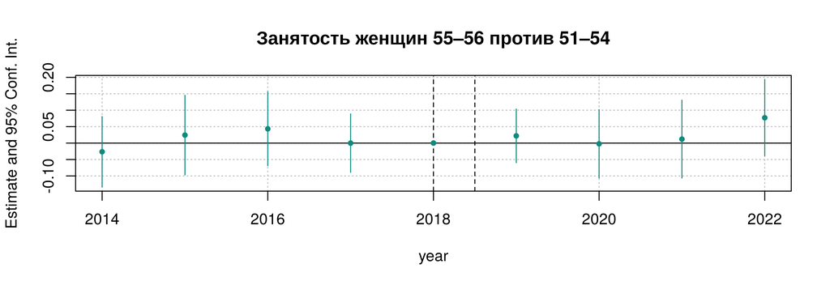

## Уровень кластеризации

```r
etable(m_did, m_did, m_did, vcov = list("hetero", ~idind, ~psu), keep = "post",
       depvar = FALSE, fitstat = ~ n, headers = c("робастные", "кластер idind", "кластер psu"))
```

|  | m_did | m_did | m_did |
| --- | --- | --- | --- |
|  | робастные | кластер idind | кластер psu |
| mother x post | 0.029*** (0.007) | 0.029*** (0.007) | 0.029*** (0.006) |
| _____________ | ________________ | ________________ | ________________ |
| S.E. type | Heterosked.-rob. | by: idind | by: psu |
| Observations | 28,546 | 28,546 | 28,546 |

# Как ошибаются

## Семь ошибок с DiD

1. Два периода, два средних, никакой проверки предтрендов
2. Предтренд есть, но «мы добавили линейный тренд» — а он и съедает эффект, и может его создать
3. Включают контроли, на которые политика влияет (число детей после 2007 г. — следствие)
4. Группу сравнения выбирают, глядя на результат
5. Переходный период (объявление → вступление в силу) считают «до» или «после» по удобству
6. Робастные ошибки вместо кластерных в панели с 10 годами
7. Разновременное включение регионов оценивают простым TWFE — лекция 10 про то, почему это ломается

## Чек-лист

- Дата политики и переходный период определены по документам
- Группы заданы **до** политики и не меняются из-за неё
- Показан динамический DiD с предтрендами
- Плацебо по времени и по группе
- Кластер по уровню назначения воздействия
- Эффект переведён в проценты от базового уровня
- Обсуждена чувствительность к нарушению параллельности

# Мини-задача

## Задание к следующему занятию

1. Прочитайте Slonimczyk & Yurko (2014): чем их выборка, исход и окно отличаются от наших? Повторите их конструкцию, насколько позволяет панель
2. С 2020 г. материнский капитал платят и за **первого** ребёнка. Постройте DiD: бездетные (теперь затронуты) против матерей, 2016–2019 vs 2021–2024. Что мешает интерпретации (подсказка: 2020 год)?
3. Повторите основной DiD с кластером по площадке и с wild cluster bootstrap (`fwildclusterboot`). Что стало с p-value?
4. Антитабачный закон 2013 г. Предложите группу сравнения для DiD и объясните, почему любая из них неидеальна

# Литература

## Что прочитать

- Slonimczyk F., Yurko A. (2014). Assessing the Effect of the Maternity Capital Policy in Russia. *Labour Economics* — исходная работа на RLMS
- Card D., Krueger A. (1994). Minimum Wages and Employment. *AER* — классический 2 × 2
- Bertrand M., Duflo E., Mullainathan S. (2004). How Much Should We Trust DiD Estimates? *QJE*
- Cunningham S. *The Mixtape*, гл. 9 «Difference-in-Differences»
- Roth J., Sant’Anna P., Bilinski A., Poe J. (2023). What’s Trending in Difference-in-Differences? *J. Econometrics* — современный обзор
- Rambachan A., Roth J. (2023). A More Credible Approach to Parallel Trends. *REStud* — `HonestDiD`

Каузальный анализ в R · RLMS-HSE · К. Аванесян

← К программе курса